# Global Disparities in Neonatal Mortality

Author

Shaun Amrein

Published

April 7, 2024

```python
import nbformat

with open("/content/drive/MyDrive/Colab Notebooks/report.ipynb", "r") as f:
    nb = nbformat.read(f, as_version=4)

yaml_cell = nbformat.v4.new_raw_cell("""---
title: "Global Disparities in Neonatal Mortality"
author: "Shaun Amrein"
date: "2024-04-07"
format:
  html:
    embed-resources: true
    code-fold: true
    theme: flatly
    toc: true
    toc-title: "Contents"
    smooth-scroll: true
execute:
  warning: false
  message: false
---""")

nb.cells.insert(0, yaml_cell)

with open("/content/report.ipynb", "w") as f:
    nbformat.write(nb, f)

print("Done!")
```

```
Done!
```

# Global Disparities in Neonatal Mortality: The Role of Infrastructure and Economic Development

## Global Inequality in Neonatal Mortality

Despite major global progress since 1990, **neonatal mortality remains concentrated in lower-income countries**. This report examines how *geography and development* shape survival outcomes in 2023.

### Key Findings:

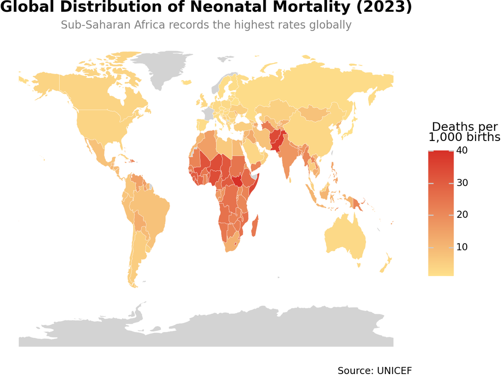

## Global Distribution of Neonatal Mortality (2023)

Mortality rates remain **highly uneven** across the globe. *Sub-Saharan Africa* records the highest levels globally, while high-income regions such as **Europe and North America** report significantly lower rates, often below 5 per 1,000 live births.

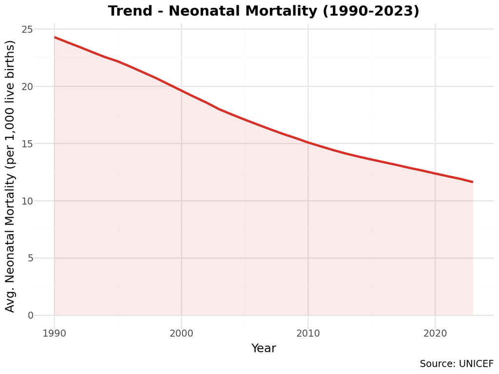

## Neonatal Mortality Trend (1990-2023)

Global neonatal mortality has **declined steadily since 1990**, reflecting significant progress in maternal and child health. However, the persistence of current rates highlights *continuing inequality* in survival outcomes. As many countries did not have data available prior to 1990, this was used as a starting point.

```
Scatter data shape: (175, 4)
```

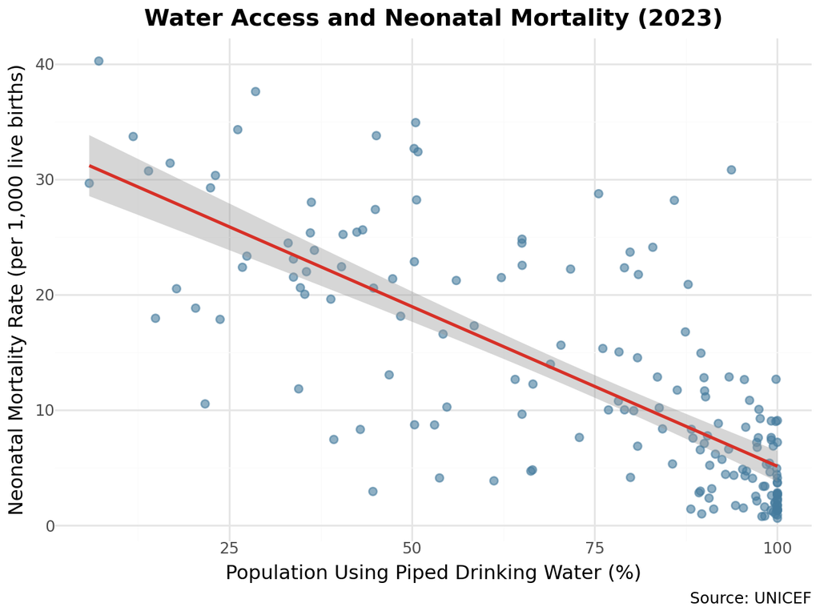

## Water Access and Neonatal Mortality

Greater access to **piped drinking water** is associated with lower neonatal mortality rates. The scatter plot demonstrates a clear *inverse relationship*, where neonatal mortality declines as water access increases, though some variation suggests that infrastructure improvements alone may not fully account for differences in survival outcomes.

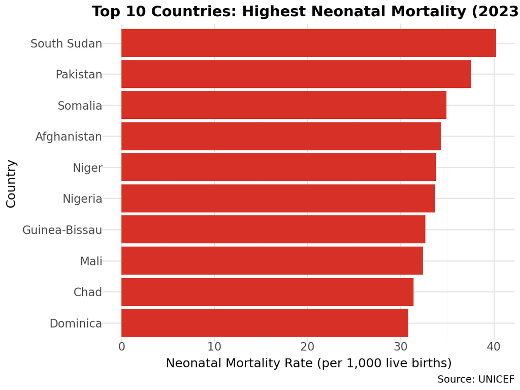